# Analyzing Fractional Factorials Workbook

Shilpa Gupta

2022-08-23

```r
library(tidyverse)
library(DoE.base)
library(FrF2)
library(rsm)
```

### Problem 6.24, 8.4, 8.5

> An experiment was run in a semiconductor fabrication plant in an effort to increase yield. Five factors, each at two levels, were studied. The factors (and levels) were A = aperture setting (small, large), B = exposure time (20% below nominal, 20% above nominal), C = development time (30 and 45 s), D = mask dimension (small, large), and E = etch time (14.5 and 15.5 min). The unreplicated $2^5$ design shown below was run.

Set up the design matrix:

```r
design_matrix <- FrF2(nruns = 32 , nfactors = 5, default.levels = c(-1, 1), factor.names = c("A", "B", "C", "D", "E"), randomize = FALSE, replications = 1)
```

```
## creating full factorial with 32 runs ...
```

```r
summary(design_matrix)
```

```
## Call:
## FrF2(nruns = 32, nfactors = 5, default.levels = c(-1, 1), factor.names = c("A",
##     "B", "C", "D", "E"), randomize = FALSE, replications = 1)
##
## Experimental design of type  full factorial
## 32  runs
##
## Factor settings:
##    A  B  C  D  E
## 1 -1 -1 -1 -1 -1
## 2  1  1  1  1  1
##
## The design itself:
##     A  B  C  D  E
## 1  -1 -1 -1 -1 -1
```

[output cut: 32 more lines]

The results are as follows:

```r
yield <- c(7, 9, 34, 55, 16, 20, 40, 60, 8, 10, 32, 50, 18, 21, 44, 61, 8, 12, 35, 52, 15, 22, 45, 65, 6, 10, 30, 53, 15, 20, 41, 63)
design_resp <- add.response(design_matrix, yield)
head(design_resp)
```

```
##    A  B  C  D  E yield
## 1 -1 -1 -1 -1 -1     7
## 2  1 -1 -1 -1 -1     9
## 3 -1  1 -1 -1 -1    34
## 4  1  1 -1 -1 -1    55
## 5 -1 -1  1 -1 -1    16
## 6  1 -1  1 -1 -1    20
```

> Construct a normal probability plot of the effect estimates. Which effects appear to be large?

Normal probability plots and half normal probability plots

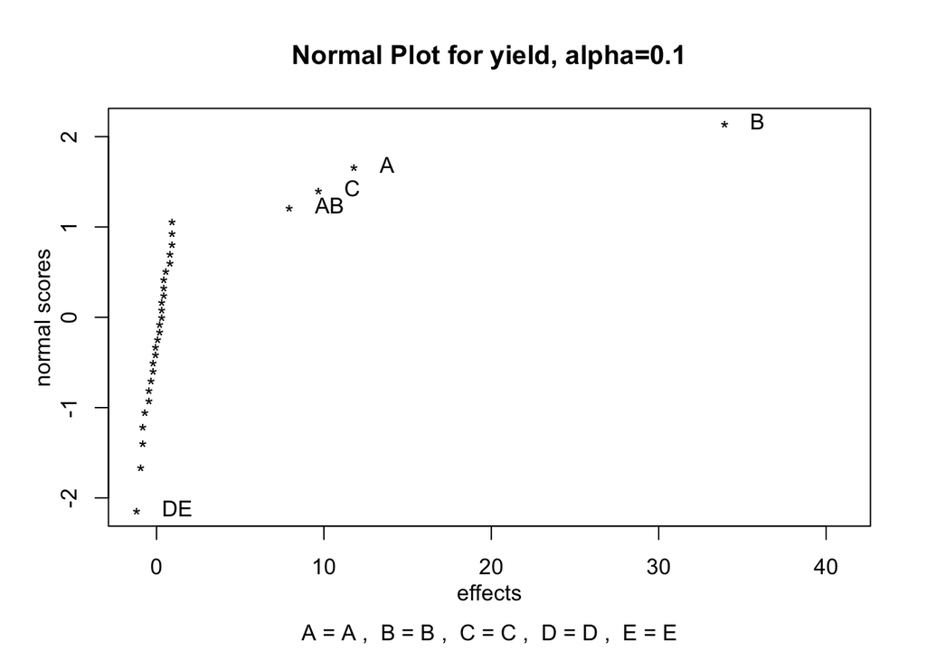

```r
DanielPlot(design_resp, code=TRUE, alpha =0.1)
```

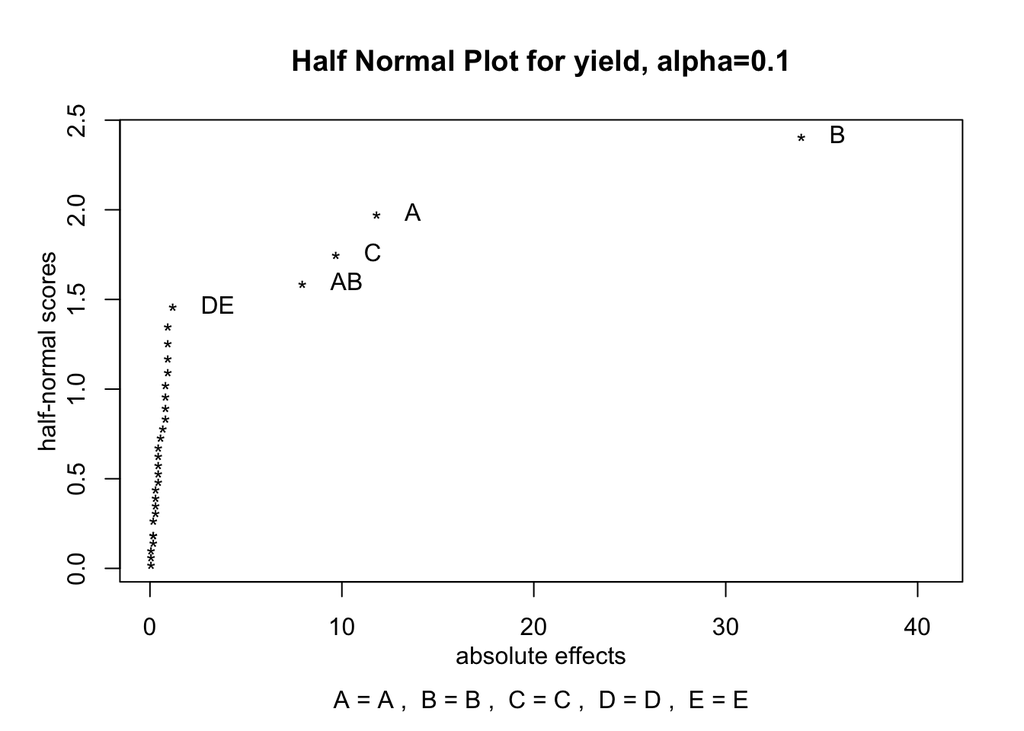

```r
DanielPlot(design_resp, code=TRUE, alpha =0.1, half = TRUE)
```

```r
fit <- aov(yield ~ A +B +C + A:B , data = design_resp)
summary(fit)
```

```
##             Df Sum Sq Mean Sq F value   Pr(>F)
## A            1   1116    1116   382.3  < 2e-16 ***
## B            1   9214    9214  3155.3  < 2e-16 ***
## C            1    751     751   257.1 2.53e-15 ***
## A:B          1    504     504   172.6 3.04e-13 ***
## Residuals   27     79       3
## ---
## Signif. codes:  0 '***' 0.001 '**' 0.01 '*' 0.05 '.' 0.1 ' ' 1
```

> Write down the regression model relating yield to the significant process variables.

```r
fit <- lm(yield ~ A+B+C+A:B , data = design_resp)
summary(fit)
```

```
##
## Call:
## lm.default(formula = yield ~ A + B + C + A:B, data = design_resp)
##
## Residuals:
##     Min      1Q  Median      3Q     Max
## -2.7812 -1.2812 -0.3438  1.2500  2.7812
##
## Coefficients:
##             Estimate Std. Error t value Pr(>|t|)
## (Intercept)  30.5312     0.3021  101.07  < 2e-16 ***
## A1            5.9063     0.3021   19.55  < 2e-16 ***
## B1           16.9688     0.3021   56.17  < 2e-16 ***
## C1            4.8438     0.3021   16.03 2.53e-15 ***
## A1:B1         3.9687     0.3021   13.14 3.04e-13 ***
## ---
## Signif. codes:  0 '***' 0.001 '**' 0.01 '*' 0.05 '.' 0.1 ' ' 1
##
## Residual standard error: 1.709 on 27 degrees of freedom
## Multiple R-squared:  0.9932, Adjusted R-squared:  0.9922
## F-statistic: 991.8 on 4 and 27 DF,  p-value: < 2.2e-16
```

> Plot the residuals on normal probability paper. Is the plot satisfactory?

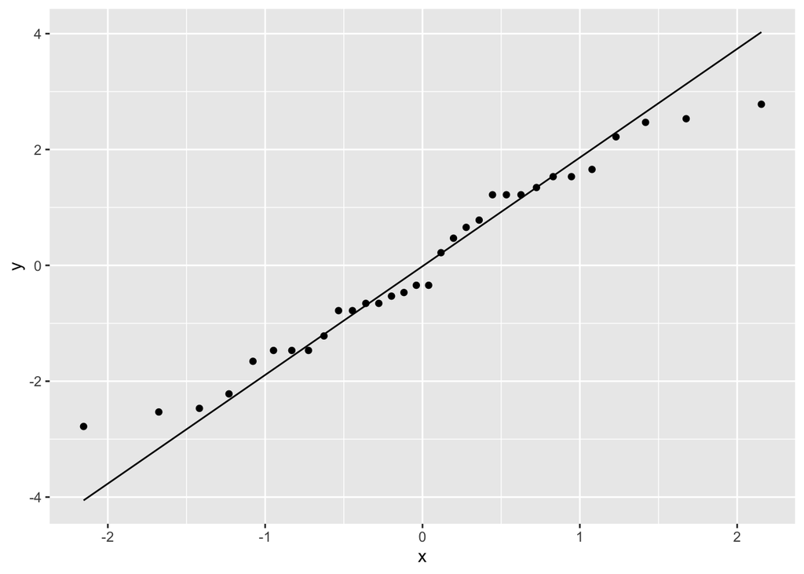

```r
#names(fit)
ggplot(data = fit, aes(sample = fit$residuals)) + stat_qq()+ stat_qq_line()
```

> Plot the residuals versus the predicted yields and versus each of the five factors. Comment on the plots.

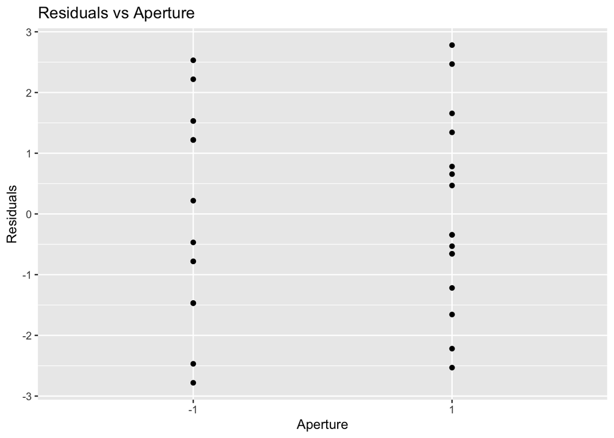

```r
full_mat <- design_resp
full_mat$resids <- fit$residuals
full_mat$fitted_values <- fit$fitted.values

ggplot(data = full_mat, aes(y = full_mat$resids, x = full_mat$A)) + geom_point() + labs(title = "Residuals vs Aperture", x = "Aperture", y="Residuals")
```

> Interpret any significant interactions.

Main Effects

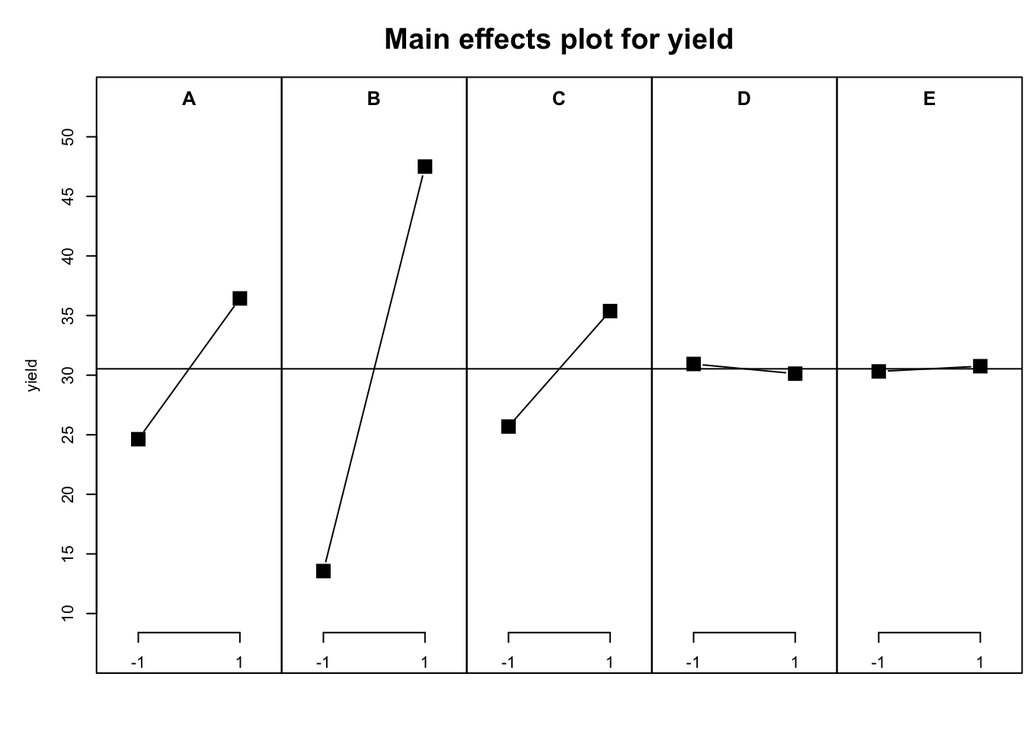

```r
MEPlot(design_resp)
```

Interaction Plots

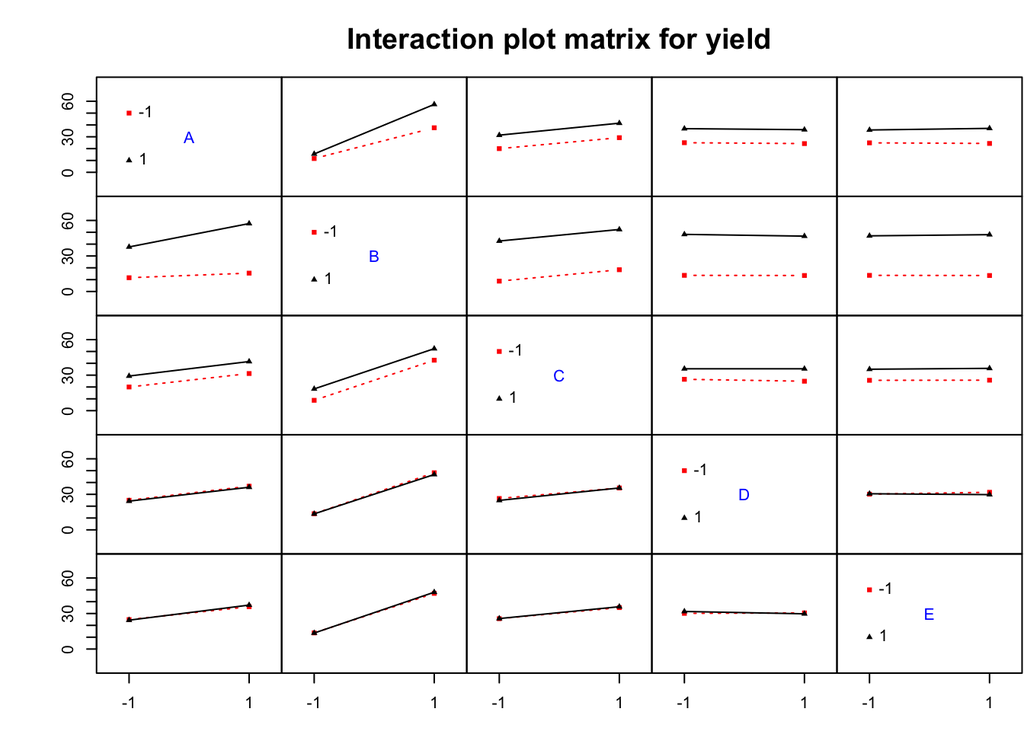

```r
IAPlot(design_resp)
```

**Please enter your comments here** Factor A does not have as large an effect when B is at its low level as it does when B is at its high level.

> What are your recommendations regarding process operating conditions?

**Please enter your comments here** To achieve the highest yield, run B at the high level, A at the high level, and C at the high level.

> Project the $2^5$ design in this problem into a $2^k$ design in the important factors. Sketch the design and show the average and range of yields at each run. Does this sketch aid in interpreting the results of this experiment?

**In Class exercise**

> Suppose that the experimenter had run four center points in addition to the 32 trials in the original experiment. The yields obtained at the center point runs were 68, 74, 76, and 70.

```r
design_matrix <- add.center(design_matrix, 4)
```

```r
yield <- c(7, 9, 34, 55, 16, 20, 40, 60, 8, 10, 32, 50, 18, 21, 44, 61, 8, 12, 35, 52, 15, 22, 45, 65, 6, 10, 30, 53, 15, 20, 41, 63, 68, 74, 76, 70)
design_resp <- add.response(design_matrix, yield)
head(design_resp)
```

```
##    A  B  C  D  E yield
## 1 -1 -1 -1 -1 -1     7
## 2  1 -1 -1 -1 -1     9
## 3 -1  1 -1 -1 -1    34
## 4  1  1 -1 -1 -1    55
## 5 -1 -1  1 -1 -1    16
## 6  1 -1  1 -1 -1    20
```

> Reanalyze the experiment, including a test for pure quadratic curvature.

```r
fit <- lm(yield ~ A + B +C + A:B+ iscube(design_resp)  , data = design_resp)
anova(fit)
```

```
## Analysis of Variance Table
##
## Response: yield
##                     Df Sum Sq Mean Sq F value    Pr(>F)
## A                    1 1116.3  1116.3  281.79 < 2.2e-16 ***
## B                    1 9214.0  9214.0 2325.92 < 2.2e-16 ***
## C                    1  750.8   750.8  189.52 1.676e-14 ***
## iscube(design_resp)  1 6114.3  6114.3 1543.46 < 2.2e-16 ***
## A:B                  1  504.0   504.0  127.23 2.578e-12 ***
## Residuals           30  118.8     4.0
## ---
## Signif. codes:  0 '***' 0.001 '**' 0.01 '*' 0.05 '.' 0.1 ' ' 1
```

```r
summary(fit)
```

```
##
## Call:
## lm.default(formula = yield ~ A + B + C + A:B + iscube(design_resp),
##     data = design_resp)
##
## Residuals:
##     Min      1Q  Median      3Q     Max
## -4.0000 -1.4688 -0.3437  1.3906  4.0000
##
## Coefficients:
##                         Estimate Std. Error t value Pr(>|t|)
## (Intercept)              72.0000     0.9952   72.35  < 2e-16 ***
## A                         5.9063     0.3518   16.79  < 2e-16 ***
## B                        16.9688     0.3518   48.23  < 2e-16 ***
## C                         4.8437     0.3518   13.77 1.68e-14 ***
## iscube(design_resp)TRUE -41.4687     1.0555  -39.29  < 2e-16 ***
## A:B                       3.9688     0.3518   11.28 2.58e-12 ***
## ---
## Signif. codes:  0 '***' 0.001 '**' 0.01 '*' 0.05 '.' 0.1 ' ' 1
##
## Residual standard error: 1.99 on 30 degrees of freedom
## Multiple R-squared:  0.9933, Adjusted R-squared:  0.9922
## F-statistic: 893.6 on 5 and 30 DF,  p-value: < 2.2e-16
```

Next step would be to add axial points for factors B and C along with four more center points to fit a second‐order model and satisfy blocking concerns.

> Suppose that only eight runs could be made in this process. Set up an appropriate $2^{5−2}$ design and use generators D = AB and E = AC. Estimate the factor effects. What conclusions can you draw?

```r
dm <- FrF2(nruns = 8 , nfactors = 5, default.levels = c(-1, 1), factor.names = c("A", "B", "C", "D", "E"), randomize = FALSE, replications = 1, generators = c("AB", "AC"))
summary(dm)
```

```
## Call:
## FrF2(nruns = 8, nfactors = 5, default.levels = c(-1, 1), factor.names = c("A",
##     "B", "C", "D", "E"), randomize = FALSE, replications = 1,
##     generators = c("AB", "AC"))
##
## Experimental design of type  FrF2.generators
## 8  runs
##
## Factor settings (scale ends):
##    A  B  C  D  E
## 1 -1 -1 -1 -1 -1
## 2  1  1  1  1  1
##
## Design generating information:
## $legend
## [1] A=A B=B C=C D=D E=E
##
## $generators
## [1] D=AB E=AC
##
##
## Alias structure:
## $main
## [1] A=BD=CE B=AD    C=AE    D=AB    E=AC
##
## $fi2
## [1] BC=DE BE=CD
##
##
## The design itself:
##    A  B  C  D  E
## 1 -1 -1 -1  1  1
## 2  1 -1 -1 -1 -1
## 3 -1  1 -1 -1  1
## 4  1  1 -1  1 -1
## 5 -1 -1  1  1 -1
## 6  1 -1  1 -1  1
## 7 -1  1  1 -1 -1
## 8  1  1  1  1  1
## class=design, type= FrF2.generators
```

```r
yield <- c(6, 9, 35, 50, 18, 22, 40, 63)
frdesign <- add.response(dm, yield)
head(frdesign)
```

```
##    A  B  C  D  E yield
## 1 -1 -1 -1  1  1     6
## 2  1 -1 -1 -1 -1     9
## 3 -1  1 -1 -1  1    35
## 4  1  1 -1  1 -1    50
## 5 -1 -1  1  1 -1    18
## 6  1 -1  1 -1  1    22
```

```
## simulated critical values not available for all requests, used conservative ones
```

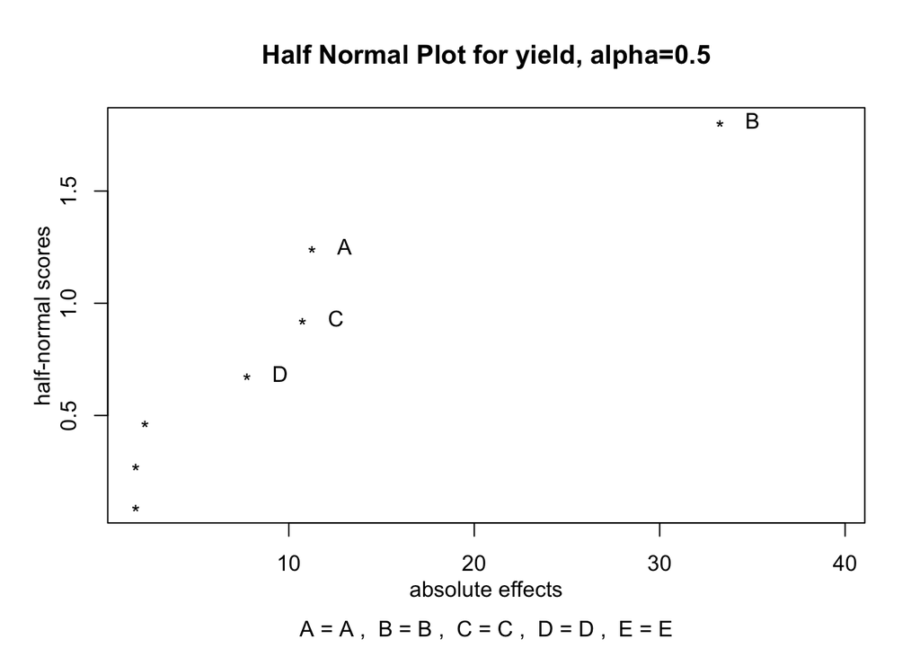

```r
DanielPlot(frdesign, code=TRUE, alpha =0.5, half = TRUE)
```

```r
fit <- lm(yield ~ A + B +C + D  , data = frdesign)
anova(fit)
```

```
## Analysis of Variance Table
##
## Response: yield
##           Df  Sum Sq Mean Sq F value    Pr(>F)
## A          1  253.13  253.13  33.938 0.0100735 *
## B          1 2211.12 2211.12 296.464 0.0004268 ***
## C          1  231.13  231.13  30.989 0.0114387 *
## D          1  120.12  120.12  16.106 0.0277670 *
## Residuals  3   22.37    7.46
## ---
## Signif. codes:  0 '***' 0.001 '**' 0.01 '*' 0.05 '.' 0.1 ' ' 1
```

```r
summary(fit)
```

```
##
## Call:
## lm.default(formula = yield ~ A + B + C + D, data = frdesign)
##
## Residuals:
##      1      2      3      4      5      6      7      8
## -0.625 -1.125  2.875 -1.125  0.625  1.125 -2.875  1.125
##
## Coefficients:
##             Estimate Std. Error t value Pr(>|t|)
## (Intercept)  30.3750     0.9656  31.459 7.06e-05 ***
## A1            5.6250     0.9656   5.826 0.010073 *
## B1           16.6250     0.9656  17.218 0.000427 ***
## C1            5.3750     0.9656   5.567 0.011439 *
## D1            3.8750     0.9656   4.013 0.027767 *
## ---
## Signif. codes:  0 '***' 0.001 '**' 0.01 '*' 0.05 '.' 0.1 ' ' 1
##
## Residual standard error: 2.731 on 3 degrees of freedom
## Multiple R-squared:  0.9921, Adjusted R-squared:  0.9816
## F-statistic: 94.37 on 4 and 3 DF,  p-value: 0.001742
```

> What additional runs would be required to identify the factor effects that are of interest? What are the alias relationships in the combined design?

```r
dm2 <- FrF2(nruns = 8 , nfactors = 5, default.levels = c(-1, 1), factor.names = c("A", "B", "C", "D", "E"), randomize = FALSE, replications = 1, generators = c("-AB", "-AC"))
summary(dm2)
```

```
## Call:
## FrF2(nruns = 8, nfactors = 5, default.levels = c(-1, 1), factor.names = c("A",
##     "B", "C", "D", "E"), randomize = FALSE, replications = 1,
##     generators = c("-AB", "-AC"))
##
## Experimental design of type  FrF2.generators
## 8  runs
##
## Factor settings (scale ends):
##    A  B  C  D  E
## 1 -1 -1 -1 -1 -1
## 2  1  1  1  1  1
##
## Design generating information:
## $legend
## [1] A=A B=B C=C D=D E=E
##
## $generators
## [1] D=-AB E=-AC
##
##
## Alias structure:
## $main
## [1] A=-BD=-CE B=-AD     C=-AE     D=-AB     E=-AC
##
## $fi2
## [1] BC=DE BE=CD
##
##
## The design itself:
##    A  B  C  D  E
## 1 -1 -1 -1 -1 -1
## 2  1 -1 -1  1  1
## 3 -1  1 -1  1 -1
## 4  1  1 -1 -1  1
## 5 -1 -1  1 -1  1
## 6  1 -1  1  1 -1
## 7 -1  1  1  1  1
## 8  1  1  1 -1 -1
## class=design, type= FrF2.generators
```

```r
yield <- c(7, 10, 32, 52, 15, 21, 41, 60)
foldover_design <- add.response(dm2, yield)
head(foldover_design)
```

```
##    A  B  C  D  E yield
## 1 -1 -1 -1 -1 -1     7
## 2  1 -1 -1  1  1    10
## 3 -1  1 -1  1 -1    32
## 4  1  1 -1 -1  1    52
## 5 -1 -1  1 -1  1    15
## 6  1 -1  1  1 -1    21
```

```r
frdesign$block <- rep(1, dim(frdesign)[1])

foldover_design$block <- rep(2, dim(foldover_design)[1])

combdata <- rbind(frdesign, foldover_design)
```

```
## simulated critical values not available for all requests, used conservative ones
```

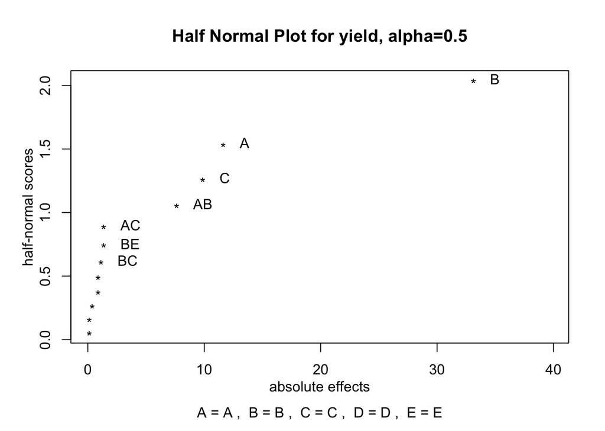

```r
DanielPlot(combdata, code=TRUE, alpha =0.5, half = TRUE)
```

```r
fit <- lm(yield ~ A + B +C + E + A:B + A:C + B:E + B:C + block  , data = combdata)
anova(fit)
```

```
## Analysis of Variance Table
##
## Response: yield
##           Df Sum Sq Mean Sq   F value    Pr(>F)
## A          1  540.6   540.6  552.0638 3.900e-07 ***
## B          1 4389.1  4389.1 4482.4468 7.468e-10 ***
## C          1  390.1   390.1  398.3617 1.027e-06 ***
## E          1    3.1     3.1    3.1277   0.12738
## block      1    1.6     1.6    1.5957   0.25337
## A:B        1  232.6   232.6  237.5106 4.719e-06 ***
## A:C        1    7.6     7.6    7.7234   0.03203 *
## B:E        1    7.6     7.6    7.7234   0.03203 *
## B:C        1    5.1     5.1    5.1702   0.06334 .
## Residuals  6    5.9     1.0
## ---
## Signif. codes:  0 '***' 0.001 '**' 0.01 '*' 0.05 '.' 0.1 ' ' 1
```

```r
summary(fit)
```

```
##
## Call:
## lm.default(formula = yield ~ A + B + C + E + A:B + A:C + B:E +
##     B:C + block, data = combdata)
##
## Residuals:
##     Min      1Q  Median      3Q     Max
## -0.8750 -0.5312  0.1250  0.2500  1.2500
##
## Coefficients:
##             Estimate Std. Error t value Pr(>|t|)
## (Intercept)   7.8750     1.0496   7.503  0.00029 ***
## A1            2.6250     0.8570   3.063  0.02214 *
## B1           25.2500     0.9895  25.517 2.39e-07 ***
## C1            9.6250     0.8570  11.232 2.98e-05 ***
## E1           -0.5000     0.6997  -0.715  0.50171
## block        -0.6250     0.4948  -1.263  0.25337
## A1:B1        15.2500     0.9895  15.411 4.72e-06 ***
## A1:C1         2.7500     0.9895   2.779  0.03203 *
## B1:E1         2.7500     0.9895   2.779  0.03203 *
## B1:C1        -2.2500     0.9895  -2.274  0.06334 .
## ---
## Signif. codes:  0 '***' 0.001 '**' 0.01 '*' 0.05 '.' 0.1 ' ' 1
##
## Residual standard error: 0.9895 on 6 degrees of freedom
## Multiple R-squared:  0.9989, Adjusted R-squared:  0.9974
## F-statistic: 632.9 on 9 and 6 DF,  p-value: 3.116e-08
```

Interaction Plots

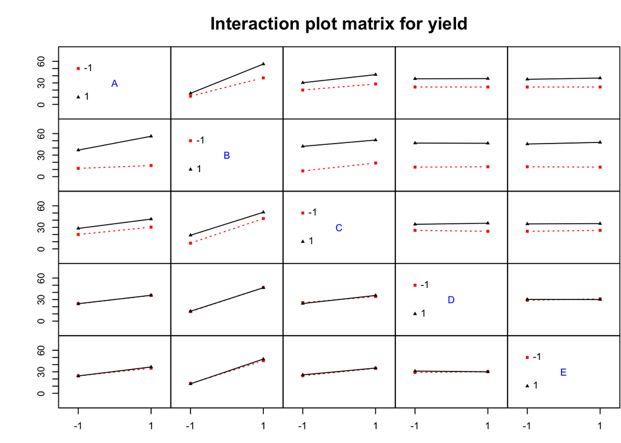

```r
IAPlot(combdata)
```

```r
library(tidyverse)
indata <- read_csv("data/DOExp_11_2.csv")
head(indata)
```

```
## # A tibble: 6 × 7
##    time  temp    x1    x2 yield viscosity molecular_weight
##   <dbl> <dbl> <dbl> <dbl> <dbl>     <dbl>            <dbl>
## 1    80   170    -1    -1  76.5        62             2940
## 2    80   180    -1     1  77          60             3470
## 3    90   170     1    -1  78          66             3680
## 4    90   180     1     1  79.5        59             3890
## 5    85   175     0     0  79.9        72             3480
## 6    85   175     0     0  80.3        69             3200
```

```r
indata2 <- slice(indata, 1:(n()-4))
```

```r
library(rsm)
rsm.fit <- rsm(yield ~ FO(x1, x2) + TWI(x1, x2) + SO(x1, x2), data = indata2)
summary(rsm.fit)
```

```
##
## Call:
## rsm(formula = yield ~ FO(x1, x2) + TWI(x1, x2) + SO(x1, x2),
##     data = indata2)
##
## Residuals:
##          1          2          3          4          5          6          7
##  0.000e+00 -6.939e-18  6.623e-18  2.628e-19 -4.000e-02  3.600e-01  6.000e-02
##          8          9
## -2.400e-01 -1.400e-01
##
## Coefficients: (1 not defined because of singularities)
##                Estimate Std. Error t value Pr(>|t|)
## (Intercept)     79.9400     0.1030 776.446 1.65e-11 ***
## FO(x1, x2)x1     1.0000     0.1151   8.687 0.000966 ***
## FO(x1, x2)x2     0.5000     0.1151   4.344 0.012217 *
## TWI(x1, x2)      0.2500     0.1151   2.172 0.095611 .
## PQ(x1, x2)x1^2  -2.1900     0.1544 -14.181 0.000144 ***
## PQ(x1, x2)x2^2       NA         NA      NA       NA
## ---
## Signif. codes:  0 '***' 0.001 '**' 0.01 '*' 0.05 '.' 0.1 ' ' 1
##
## Residual standard error: 0.2302 on 4 degrees of freedom
## Multiple R-squared:  0.9868, Adjusted R-squared:  0.9737
## F-statistic: 75.04 on 4 and 4 DF,  p-value: 0.0005143
```

```r
anova(rsm.fit)
```

```
## Analysis of Variance Table
##
## Response: yield
##             Df Sum Sq Mean Sq F value    Pr(>F)
## FO(x1, x2)   2  5.000   2.500  47.170 0.0016545 **
## TWI(x1, x2)  1  0.250   0.250   4.717 0.0956108 .
## PQ(x1, x2)   1 10.658  10.658 201.094 0.0001436 ***
## Residuals    4  0.212   0.053
## ---
## Signif. codes:  0 '***' 0.001 '**' 0.01 '*' 0.05 '.' 0.1 ' ' 1
```

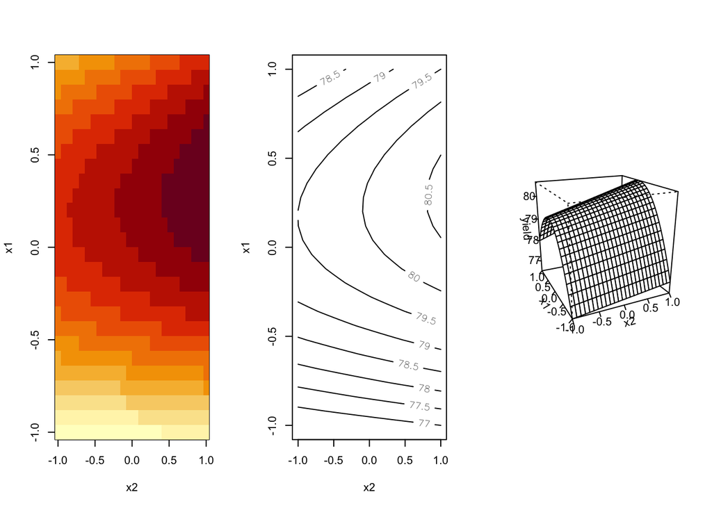

```r
par(mfrow=c(1,3))
image(rsm.fit, x1 ~ x2)
contour(rsm.fit, x1 ~ x2)
persp(rsm.fit, x1 ~ x2, zlab = "yield")
```